# RCT Ketosis

Prelim analysis

11/05/2021

## Analysis for animals under treatments 1,2, 3.

For this analysis animals labeled as controls were removed because they were not truly controls of the treatments. This analysis is focused on animals under treatment 1, 2, 3. First, Two descriptive tables show the distribution of BHB mean and standard deviation for each treatment and day. The first table shows the results for BHB transformed to Log scale and the second one the mean for BHB in the original scale.

We tested if the interaction Day*Treatment is significant. The model shows that interaction is not significant. This means that the effect of the treatments is consistent over time and interaction will not be considered into the final model.

```
##    Day Treatment count     mean        sd
## 1    0         1    18 2.951788 0.3429346
## 2    0         2    18 2.913428 0.3462316
## 3    0         3    19 3.040395 0.4486076
## 4    3         1    18 2.471059 0.5484795
## 5    3         2    18 2.503203 0.5841902
## 6    3         3    19 2.089282 0.6615862
## 7    7         1    18 2.413736 0.5847930
## 8    7         2    18 2.410240 0.6602600
## 9    7         3    19 2.170737 0.3172922
## 10  14         1    18 2.445325 0.7599960
## 11  14         2    18 2.332037 0.6188967
## 12  14         3    19 2.094390 0.5687377
```

```
##    Day Treatment count      mean        sd
## 1    0         1    18 20.283333  7.493468
## 2    0         2    18 19.538889  7.214050
## 3    0         3    19 22.952632 10.012457
## 4    3         1    18 13.966667 10.173726
## 5    3         2    18 14.538889  9.744751
## 6    3         3    19 10.268421  8.716718
## 7    7         1    18 13.250000  8.553929
## 8    7         2    18 13.605556  9.722955
## 9    7         3    19  9.194737  2.985237
## 10  14         1    18 15.361111 12.872046
## 11  14         2    18 12.772222 10.649043
## 12  14         3    19  9.505263  6.116596
```

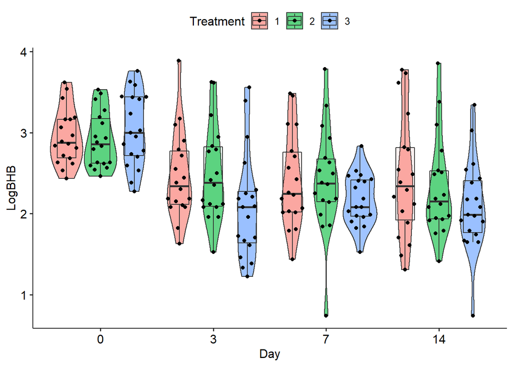

```
## Linear mixed model fit by REML. t-tests use Satterthwaite's method [
## lmerModLmerTest]
## Formula: BHB ~ Treatment * Day + (1 | Cow)
##    Data: ketosis2
##
## REML criterion at convergence: 1510
##
## Scaled residuals:
##     Min      1Q  Median      3Q     Max
## -1.8060 -0.5215 -0.1648  0.3433  3.4240
##
## Random effects:
##  Groups   Name        Variance Std.Dev.
##  Cow      (Intercept) 27.76    5.269
##  Residual             53.08    7.285
## Number of obs: 220, groups:  Cow, 55
##
## Fixed effects:
##                  Estimate Std. Error       df t value Pr(>|t|)
## (Intercept)       20.2833     2.1192 153.6413   9.571  < 2e-16 ***
## Treatment2        -0.7444     2.9970 153.6413  -0.248  0.80416
## Treatment3         2.6693     2.9573 153.6413   0.903  0.36815
## Day3              -6.3167     2.4285 156.0000  -2.601  0.01019 *
## Day7              -7.0333     2.4285 156.0000  -2.896  0.00432 **
## Day14             -4.9222     2.4285 156.0000  -2.027  0.04438 *
## Treatment2:Day3    1.3167     3.4344 156.0000   0.383  0.70196
## Treatment3:Day3   -6.3675     3.3889 156.0000  -1.879  0.06212 .
## Treatment2:Day7    1.1000     3.4344 156.0000   0.320  0.74918
## Treatment3:Day7   -6.7246     3.3889 156.0000  -1.984  0.04898 *
## Treatment2:Day14  -1.8444     3.4344 156.0000  -0.537  0.59200
## Treatment3:Day14  -8.5251     3.3889 156.0000  -2.516  0.01290 *
## ---
## Signif. codes:  0 '***' 0.001 '**' 0.01 '*' 0.05 '.' 0.1 ' ' 1
##
## Correlation of Fixed Effects:
##             (Intr) Trtmn2 Trtmn3 Day3   Day7   Day14  Tr2:D3 Tr3:D3 Tr2:D7
## Treatment2  -0.707
## Treatment3  -0.717  0.507
## Day3        -0.573  0.405  0.411
## Day7        -0.573  0.405  0.411  0.500
## Day14       -0.573  0.405  0.411  0.500  0.500
## Trtmnt2:Dy3  0.405 -0.573 -0.290 -0.707 -0.354 -0.354
## Trtmnt3:Dy3  0.411 -0.290 -0.573 -0.717 -0.358 -0.358  0.507
## Trtmnt2:Dy7  0.405 -0.573 -0.290 -0.354 -0.707 -0.354  0.500  0.253
## Trtmnt3:Dy7  0.411 -0.290 -0.573 -0.358 -0.717 -0.358  0.253  0.500  0.507
## Trtmnt2:D14  0.405 -0.573 -0.290 -0.354 -0.354 -0.707  0.500  0.253  0.500
## Trtmnt3:D14  0.411 -0.290 -0.573 -0.358 -0.358 -0.717  0.253  0.500  0.253
##             Tr3:D7 T2:D14
## Treatment2
## Treatment3
## Day3
## Day7
## Day14
## Trtmnt2:Dy3
## Trtmnt3:Dy3
## Trtmnt2:Dy7
## Trtmnt3:Dy7
## Trtmnt2:D14  0.253
## Trtmnt3:D14  0.500  0.507
```

```
## Type III Analysis of Variance Table with Satterthwaite's method
##                Sum Sq Mean Sq NumDF DenDF F value    Pr(>F)
## Treatment       99.55   49.77     2    52  0.9377    0.3980
## Day           2951.74  983.91     3   156 18.5370 2.453e-10 ***
## Treatment:Day  555.66   92.61     6   156  1.7448    0.1141
## ---
## Signif. codes:  0 '***' 0.001 '**' 0.01 '*' 0.05 '.' 0.1 ' ' 1
```

## Interpretation of the model transforming BHB to Log scale.

It can be inferred that Day 3 is significantly associated with an average decrease of 46.21% in BHB compared to Day 0, having the same value on the Treatment constant.

It can be inferred that Day 7 is significantly associated with an average decrease of 47.3% in BHB compared to Day 0, having the same value on the Treatment constant.

It can be inferred that Day 14 is significantly associated with an average decrease of 49.5% in BHB compared to Day 0, having the same value on the Treatment constant.

On the other hand:

It can be inferred that Treatment 2 is associated with an average decrease of 3% in BHB compared to Treatment 1, having the same value on Day constant. This association was not statistically significant.

It can be inferred that Treatment 3 is associated with an average decrease of 20% in BHB compared to Treatment 1, having the same value on Day constant. This association was not statistically significant.

```
## Linear mixed model fit by REML. t-tests use Satterthwaite's method [
## lmerModLmerTest]
## Formula: BHB ~ Treatment + Day + (1 | Cow)
##    Data: ketosis2
##
## REML criterion at convergence: 1543.9
##
## Scaled residuals:
##     Min      1Q  Median      3Q     Max
## -1.8031 -0.5217 -0.2390  0.2535  3.6142
##
## Random effects:
##  Groups   Name        Variance Std.Dev.
##  Cow      (Intercept) 27.40    5.234
##  Residual             54.54    7.385
## Number of obs: 220, groups:  Cow, 55
##
## Fixed effects:
##             Estimate Std. Error       df t value Pr(>|t|)
## (Intercept)  22.1035     1.7388  88.4466  12.712  < 2e-16 ***
## Treatment2   -0.6014     2.1352  52.0000  -0.282    0.779
## Treatment3   -2.7350     2.1069  52.0000  -1.298    0.200
## Day3         -8.0855     1.4083 162.0000  -5.741 4.52e-08 ***
## Day7         -8.9964     1.4083 162.0000  -6.388 1.71e-09 ***
## Day14        -8.4709     1.4083 162.0000  -6.015 1.16e-08 ***
## ---
## Signif. codes:  0 '***' 0.001 '**' 0.01 '*' 0.05 '.' 0.1 ' ' 1
##
## Correlation of Fixed Effects:
##            (Intr) Trtmn2 Trtmn3 Day3   Day7
## Treatment2 -0.614
## Treatment3 -0.622  0.507
## Day3       -0.405  0.000  0.000
## Day7       -0.405  0.000  0.000  0.500
## Day14      -0.405  0.000  0.000  0.500  0.500
```

```
## Type III Analysis of Variance Table with Satterthwaite's method
##            Sum Sq Mean Sq NumDF DenDF F value    Pr(>F)
## Treatment  102.29   51.15     2    52  0.9377     0.398
## Day       3015.65 1005.22     3   162 18.4299 2.452e-10 ***
## ---
## Signif. codes:  0 '***' 0.001 '**' 0.01 '*' 0.05 '.' 0.1 ' ' 1
```

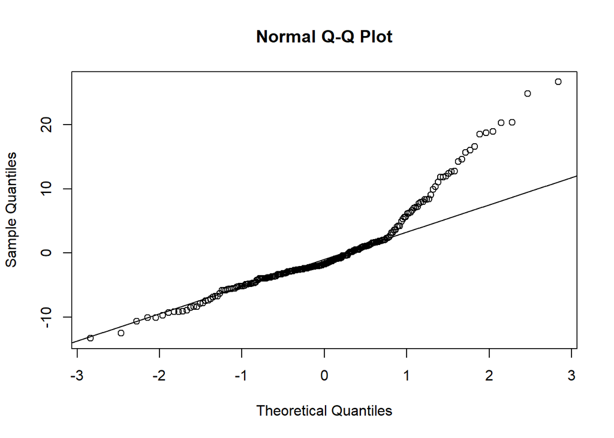

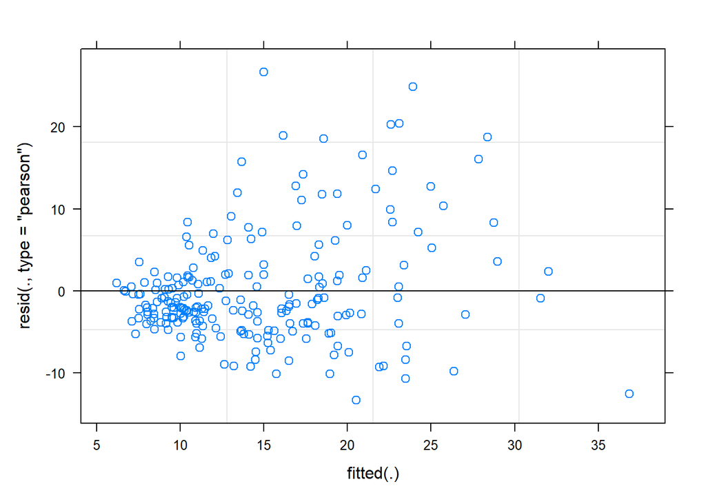

```
## Linear mixed model fit by REML. t-tests use Satterthwaite's method [
## lmerModLmerTest]
## Formula: log(BHB) ~ Treatment + Day + (1 | Cow)
##    Data: ketosis2
##
## REML criterion at convergence: 353.4
##
## Scaled residuals:
##      Min       1Q   Median       3Q      Max
## -2.59515 -0.57471 -0.07406  0.44946  2.91449
##
## Random effects:
##  Groups   Name        Variance Std.Dev.
##  Cow      (Intercept) 0.09612  0.3100
##  Residual             0.21285  0.4614
## Number of obs: 220, groups:  Cow, 55
##
## Fixed effects:
##              Estimate Std. Error        df t value Pr(>|t|)
## (Intercept)   3.05652    0.10582  91.16909  28.883  < 2e-16 ***
## Treatment2   -0.03075    0.12881  51.99999  -0.239   0.8123
## Treatment3   -0.22178    0.12710  51.99999  -1.745   0.0869 .
## Day3         -0.62015    0.08798 162.00001  -7.049 4.92e-11 ***
## Day7         -0.64120    0.08798 162.00001  -7.288 1.31e-11 ***
## Day14        -0.68283    0.08798 162.00001  -7.761 8.94e-13 ***
## ---
## Signif. codes:  0 '***' 0.001 '**' 0.01 '*' 0.05 '.' 0.1 ' ' 1
##
## Correlation of Fixed Effects:
##            (Intr) Trtmn2 Trtmn3 Day3   Day7
## Treatment2 -0.609
## Treatment3 -0.617  0.507
## Day3       -0.416  0.000  0.000
## Day7       -0.416  0.000  0.000  0.500
## Day14      -0.416  0.000  0.000  0.500  0.500
```

```
## Type III Analysis of Variance Table with Satterthwaite's method
##            Sum Sq Mean Sq NumDF DenDF F value    Pr(>F)
## Treatment  0.7673  0.3837     2    52  1.8024     0.175
## Day       17.4361  5.8120     3   162 27.3055 2.405e-14 ***
## ---
## Signif. codes:  0 '***' 0.001 '**' 0.01 '*' 0.05 '.' 0.1 ' ' 1
```

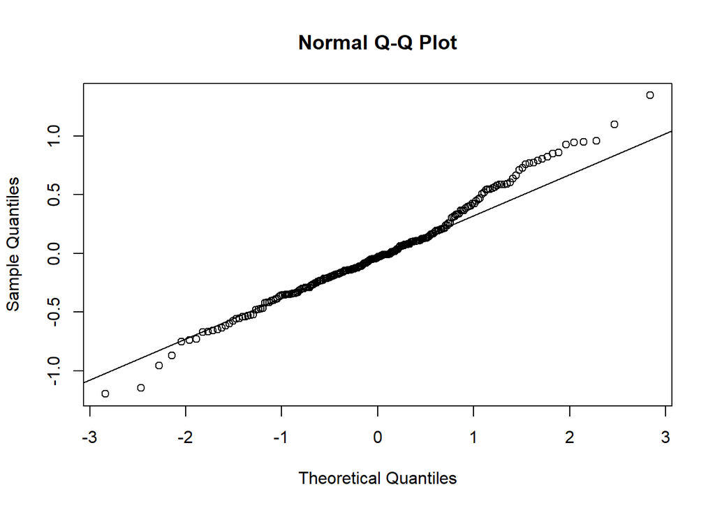

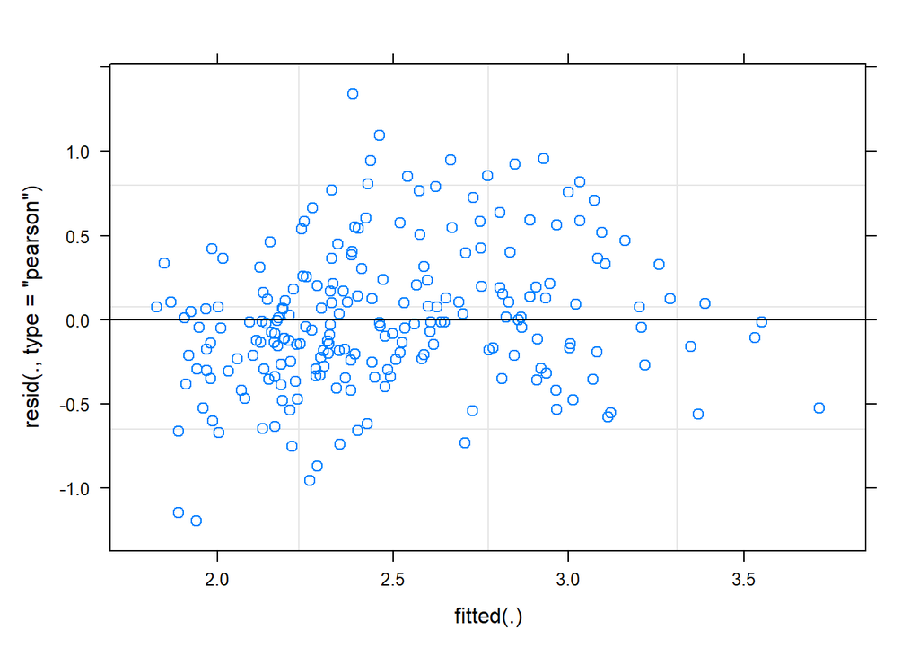

## NEFA outcome

For this analysis animals labeled as controls were removed because they were not truly controls of the treatments. This analysis is focused on animals under treatment 1, 2, 3. First, Two descriptive tables show the distribution of NEFA mean and standard deviation for each treatment and day. The first table shows the results for transformed to Log scale and the second one the mean for NEFA in the original scale.

Second, a violin graph shows us the distribution of NEFA across the days and treatments using the original scale for NEFA. This graph allows us to see the extreme values as tails instead of outliers as a box plot does. From this descriptive graph, we see that apparently there are no big differences between treatments, however, there are some differences between days.

We tested if the interaction Day*Treatment is significant. The model shows that interaction is not significant. This means that the effect of the treatments is consistent over time and interaction will not be considered into the final model.

```
##    Day Treatment count       mean        sd
## 1    0         1    14 -0.5167268 0.4590530
## 2    0         2    14 -0.5962487 0.6457349
## 3    0         3    16 -0.5138612 0.5685007
## 4    3         1    14 -0.7217189 0.3640797
## 5    3         2    14 -0.7033589 0.4094680
## 6    3         3    16 -0.7385168 0.4058594
## 7    7         1    14 -0.8404120 0.4723691
## 8    7         2    14 -0.7474543 0.4568234
## 9    7         3    16 -0.7550988 0.4308997
## 10  14         1    14 -0.6913652 0.6051278
## 11  14         2    14 -0.7732392 0.4977410
## 12  14         3    16 -0.8471135 0.4144477
```

```
##    Day Treatment count      mean        sd
## 1    0         1    14 0.6521429 0.2650741
## 2    0         2    14 0.6621429 0.4160284
## 3    0         3    16 0.6818750 0.3263172
## 4    3         1    14 0.5142857 0.1681901
## 5    3         2    14 0.5321429 0.2008129
## 6    3         3    16 0.5150000 0.2016267
## 7    7         1    14 0.4742857 0.1991796
## 8    7         2    14 0.5150000 0.2023230
## 9    7         3    16 0.5112500 0.2118451
## 10  14         1    14 0.5878571 0.3508710
## 11  14         2    14 0.5157143 0.2526997
## 12  14         3    16 0.4637500 0.1878962
```

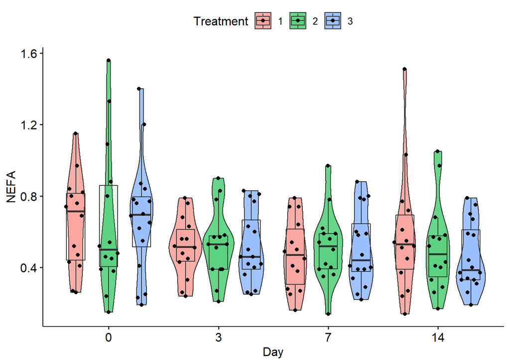

```
## Linear mixed model fit by REML. t-tests use Satterthwaite's method [
## lmerModLmerTest]
## Formula: NEFA ~ Treatment * Day + (1 | Cow)
##    Data: ketosis3
##
## REML criterion at convergence: 17.3
##
## Scaled residuals:
##     Min      1Q  Median      3Q     Max
## -1.9923 -0.5725 -0.0278  0.3624  4.0149
##
## Random effects:
##  Groups   Name        Variance Std.Dev.
##  Cow      (Intercept) 0.02917  0.1708
##  Residual             0.03756  0.1938
## Number of obs: 176, groups:  Cow, 44
##
## Fixed effects:
##                    Estimate Std. Error         df t value Pr(>|t|)
## (Intercept)        0.652143   0.069039 104.251568   9.446 1.14e-15 ***
## Treatment2         0.010000   0.097636 104.251568   0.102   0.9186
## Treatment3         0.029732   0.094536 104.251568   0.315   0.7538
## Day3              -0.137857   0.073255 123.000000  -1.882   0.0622 .
## Day7              -0.177857   0.073255 123.000000  -2.428   0.0166 *
## Day14             -0.064286   0.073255 123.000000  -0.878   0.3819
## Treatment2:Day3    0.007857   0.103598 123.000000   0.076   0.9397
## Treatment3:Day3   -0.029018   0.100308 123.000000  -0.289   0.7728
## Treatment2:Day7    0.030714   0.103598 123.000000   0.296   0.7674
## Treatment3:Day7    0.007232   0.100308 123.000000   0.072   0.9426
## Treatment2:Day14  -0.082143   0.103598 123.000000  -0.793   0.4294
## Treatment3:Day14  -0.153839   0.100308 123.000000  -1.534   0.1277
## ---
## Signif. codes:  0 '***' 0.001 '**' 0.01 '*' 0.05 '.' 0.1 ' ' 1
##
## Correlation of Fixed Effects:
##             (Intr) Trtmn2 Trtmn3 Day3   Day7   Day14  Tr2:D3 Tr3:D3 Tr2:D7
## Treatment2  -0.707
## Treatment3  -0.730  0.516
## Day3        -0.531  0.375  0.387
## Day7        -0.531  0.375  0.387  0.500
## Day14       -0.531  0.375  0.387  0.500  0.500
## Trtmnt2:Dy3  0.375 -0.531 -0.274 -0.707 -0.354 -0.354
## Trtmnt3:Dy3  0.387 -0.274 -0.531 -0.730 -0.365 -0.365  0.516
## Trtmnt2:Dy7  0.375 -0.531 -0.274 -0.354 -0.707 -0.354  0.500  0.258
## Trtmnt3:Dy7  0.387 -0.274 -0.531 -0.365 -0.730 -0.365  0.258  0.500  0.516
## Trtmnt2:D14  0.375 -0.531 -0.274 -0.354 -0.354 -0.707  0.500  0.258  0.500
## Trtmnt3:D14  0.387 -0.274 -0.531 -0.365 -0.365 -0.730  0.258  0.500  0.258
##             Tr3:D7 T2:D14
## Treatment2
## Treatment3
## Day3
## Day7
## Day14
## Trtmnt2:Dy3
## Trtmnt3:Dy3
## Trtmnt2:Dy7
## Trtmnt3:Dy7
## Trtmnt2:D14  0.258
## Trtmnt3:D14  0.500  0.516
```

```
## Type III Analysis of Variance Table with Satterthwaite's method
##                Sum Sq  Mean Sq NumDF DenDF F value    Pr(>F)
## Treatment     0.00187 0.000937     2    41  0.0250 0.9753693
## Day           0.76299 0.254330     3   123  6.7707 0.0002902 ***
## Treatment:Day 0.13191 0.021984     6   123  0.5853 0.7415464
## ---
## Signif. codes:  0 '***' 0.001 '**' 0.01 '*' 0.05 '.' 0.1 ' ' 1
```

## Interpretation of the model transforming NEFA to Log scale.

It can be inferred that Day 3 is significantly associated with an average decrease of 16.55% in NEFA compared to Day 0, having the same value on the Treatment constant.

It can be inferred that Day 7 is significantly associated with an average decrease of 21.24% in NEFA compared to Day 0, having the same value on the Treatment constant.

It can be inferred that Day 14 is significantly associated with an average decrease of 20.8% in NEFA compared to Day 0, having the same value on the Treatment constant.

On the other hand:

It can be inferred that Treatment 2 is associated with an average decrease of 1.2% in NEFA compared to Treatment 1, having the same value on Day constant. This association was not statistically significant.

It can be inferred that Treatment 3 is associated with an average decrease of 2.1% in NEFA compared to Treatment 1, having the same value on Day constant. This association was not statistically significant.

From the random effects, we can infer that 59% of the variability observed in NEFA is accounted for by the effect of the repeated measures. This indicates that account for the effect of repeated measures using a random intercept model was a good choice.

```
## Linear mixed model fit by REML. t-tests use Satterthwaite's method [
## lmerModLmerTest]
## Formula: NEFA ~ Treatment + Day + (1 | Cow)
##    Data: ketosis3
##
## REML criterion at convergence: 2.1
##
## Scaled residuals:
##     Min      1Q  Median      3Q     Max
## -2.1177 -0.5652 -0.0251  0.3613  4.3760
##
## Random effects:
##  Groups   Name        Variance Std.Dev.
##  Cow      (Intercept) 0.02935  0.1713
##  Residual             0.03684  0.1919
## Number of obs: 176, groups:  Cow, 44
##
## Fixed effects:
##               Estimate Std. Error         df t value Pr(>|t|)
## (Intercept)  6.716e-01  5.816e-02  6.082e+01  11.548  < 2e-16 ***
## Treatment2  -8.929e-04  7.422e-02  4.100e+01  -0.012 0.990460
## Treatment3  -1.417e-02  7.186e-02  4.100e+01  -0.197 0.844610
## Day3        -1.459e-01  4.092e-02  1.290e+02  -3.566 0.000510 ***
## Day7        -1.655e-01  4.092e-02  1.290e+02  -4.043 9.01e-05 ***
## Day14       -1.464e-01  4.092e-02  1.290e+02  -3.577 0.000491 ***
## ---
## Signif. codes:  0 '***' 0.001 '**' 0.01 '*' 0.05 '.' 0.1 ' ' 1
##
## Correlation of Fixed Effects:
##            (Intr) Trtmn2 Trtmn3 Day3   Day7
## Treatment2 -0.638
## Treatment3 -0.659  0.516
## Day3       -0.352  0.000  0.000
## Day7       -0.352  0.000  0.000  0.500
## Day14      -0.352  0.000  0.000  0.500  0.500
```

```
## Type III Analysis of Variance Table with Satterthwaite's method
##            Sum Sq  Mean Sq NumDF DenDF F value    Pr(>F)
## Treatment 0.00184 0.000919     2    41  0.0250 0.9753693
## Day       0.77917 0.259723     3   129  7.0502 0.0001996 ***
## ---
## Signif. codes:  0 '***' 0.001 '**' 0.01 '*' 0.05 '.' 0.1 ' ' 1
```

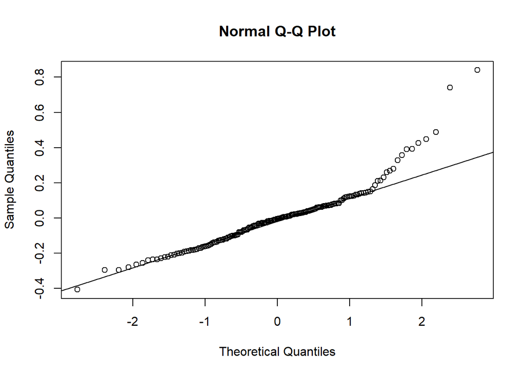

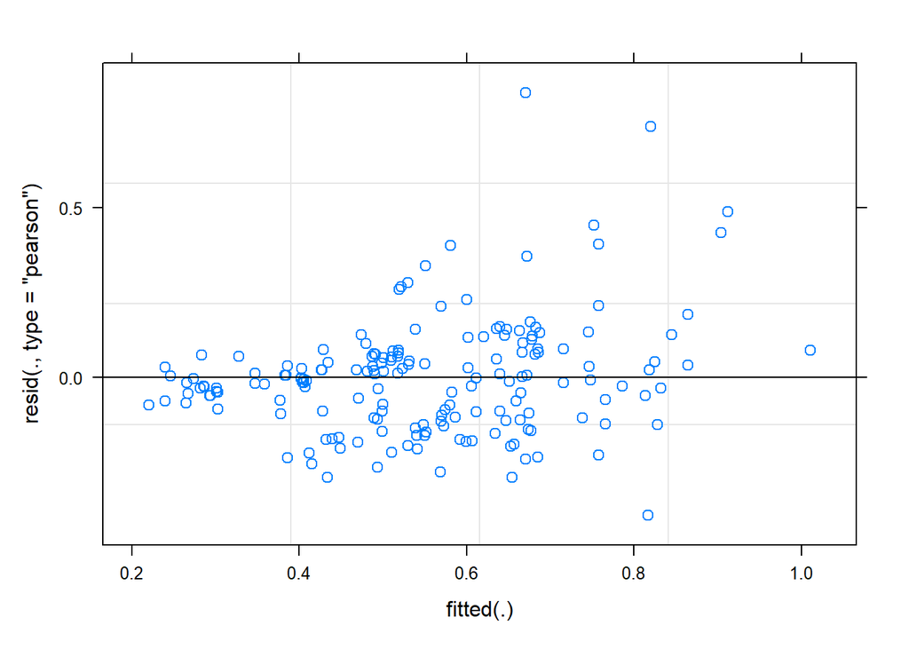

```
## Linear mixed model fit by REML. t-tests use Satterthwaite's method [
## lmerModLmerTest]
## Formula: log(NEFA) ~ Treatment + Day + (1 | Cow)
##    Data: ketosis3
##
## REML criterion at convergence: 181.8
##
## Scaled residuals:
##      Min       1Q   Median       3Q      Max
## -2.67639 -0.55588  0.07398  0.45752  3.13335
##
## Random effects:
##  Groups   Name        Variance Std.Dev.
##  Cow      (Intercept) 0.13824  0.3718
##  Residual             0.09401  0.3066
## Number of obs: 176, groups:  Cow, 44
##
## Fixed effects:
##              Estimate Std. Error        df t value Pr(>|t|)
## (Intercept)  -0.52933    0.11470  52.83965  -4.615 2.54e-05 ***
## Treatment2   -0.01252    0.15201  41.00000  -0.082 0.934760
## Treatment3   -0.02109    0.14718  41.00000  -0.143 0.886751
## Day3         -0.18100    0.06537 129.00000  -2.769 0.006456 **
## Day7         -0.23882    0.06537 129.00000  -3.653 0.000375 ***
## Day14        -0.23306    0.06537 129.00000  -3.565 0.000511 ***
## ---
## Signif. codes:  0 '***' 0.001 '**' 0.01 '*' 0.05 '.' 0.1 ' ' 1
##
## Correlation of Fixed Effects:
##            (Intr) Trtmn2 Trtmn3 Day3   Day7
## Treatment2 -0.663
## Treatment3 -0.684  0.516
## Day3       -0.285  0.000  0.000
## Day7       -0.285  0.000  0.000  0.500
## Day14      -0.285  0.000  0.000  0.500  0.500
```

```
## Type III Analysis of Variance Table with Satterthwaite's method
##            Sum Sq Mean Sq NumDF DenDF F value    Pr(>F)
## Treatment 0.00194 0.00097     2    41  0.0103 0.9897397
## Day       1.65225 0.55075     3   129  5.8582 0.0008789 ***
## ---
## Signif. codes:  0 '***' 0.001 '**' 0.01 '*' 0.05 '.' 0.1 ' ' 1
```

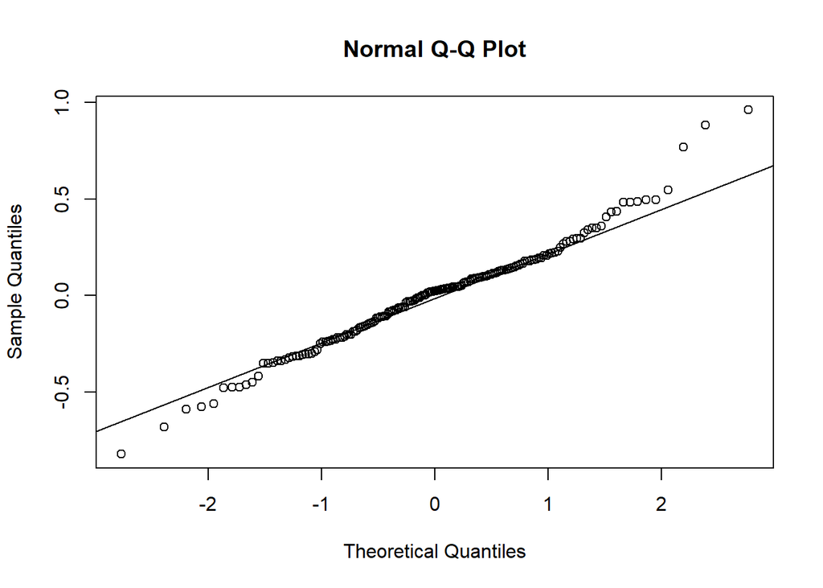

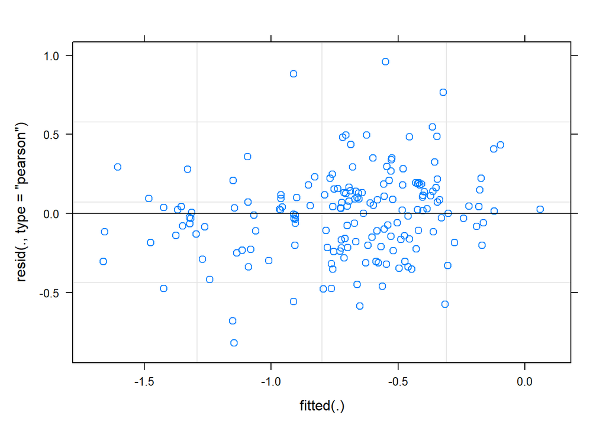

```
##    Day Treatment count     mean       sd
## 1    0         1    14 7.928571 2.129077
## 2    0         2    14 9.428571 3.298351
## 3    0         3    16 9.000000 4.516636
## 4    3         1    14 6.071429 2.702258
## 5    3         2    14 8.285714 2.493949
## 6    3         3    16 8.937500 3.453863
## 7    7         1    14 6.642857 3.201133
## 8    7         2    14 7.642857 2.951066
## 9    7         3    16 6.125000 2.473190
## 10  14         1    14 8.142857 4.817550
## 11  14         2    14 7.214286 2.547354
## 12  14         3    16 7.687500 2.600481
```

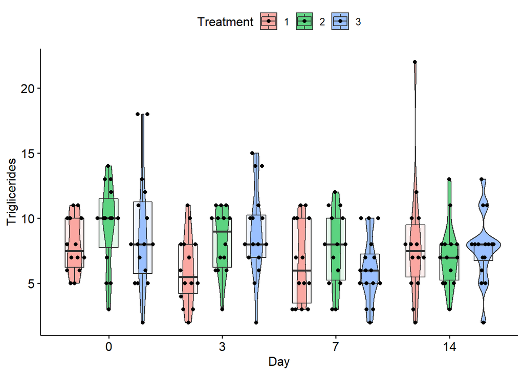

```
## Linear mixed model fit by REML. t-tests use Satterthwaite's method [
## lmerModLmerTest]
## Formula: Triglicerides ~ Treatment * Day + (1 | Cow)
##    Data: ketosis4
##
## REML criterion at convergence: 877.2
##
## Scaled residuals:
##     Min      1Q  Median      3Q     Max
## -2.1061 -0.5490 -0.0737  0.5761  4.0819
##
## Random effects:
##  Groups   Name        Variance Std.Dev.
##  Cow      (Intercept) 1.134    1.065
##  Residual             9.151    3.025
## Number of obs: 176, groups:  Cow, 44
##
## Fixed effects:
##                  Estimate Std. Error       df t value Pr(>|t|)
## (Intercept)        7.9286     0.8571 158.2277   9.250   <2e-16 ***
## Treatment2         1.5000     1.2122 158.2277   1.237    0.218
## Treatment3         1.0714     1.1737 158.2277   0.913    0.363
## Day3              -1.8571     1.1434 123.0000  -1.624    0.107
## Day7              -1.2857     1.1434 123.0000  -1.125    0.263
## Day14              0.2143     1.1434 123.0000   0.187    0.852
## Treatment2:Day3    0.7143     1.6170 123.0000   0.442    0.659
## Treatment3:Day3    1.7946     1.5656 123.0000   1.146    0.254
## Treatment2:Day7   -0.5000     1.6170 123.0000  -0.309    0.758
## Treatment3:Day7   -1.5893     1.5656 123.0000  -1.015    0.312
## Treatment2:Day14  -2.4286     1.6170 123.0000  -1.502    0.136
## Treatment3:Day14  -1.5268     1.5656 123.0000  -0.975    0.331
## ---
## Signif. codes:  0 '***' 0.001 '**' 0.01 '*' 0.05 '.' 0.1 ' ' 1
##
## Correlation of Fixed Effects:
##             (Intr) Trtmn2 Trtmn3 Day3   Day7   Day14  Tr2:D3 Tr3:D3 Tr2:D7
## Treatment2  -0.707
## Treatment3  -0.730  0.516
## Day3        -0.667  0.472  0.487
## Day7        -0.667  0.472  0.487  0.500
## Day14       -0.667  0.472  0.487  0.500  0.500
## Trtmnt2:Dy3  0.472 -0.667 -0.344 -0.707 -0.354 -0.354
## Trtmnt3:Dy3  0.487 -0.344 -0.667 -0.730 -0.365 -0.365  0.516
## Trtmnt2:Dy7  0.472 -0.667 -0.344 -0.354 -0.707 -0.354  0.500  0.258
## Trtmnt3:Dy7  0.487 -0.344 -0.667 -0.365 -0.730 -0.365  0.258  0.500  0.516
## Trtmnt2:D14  0.472 -0.667 -0.344 -0.354 -0.354 -0.707  0.500  0.258  0.500
## Trtmnt3:D14  0.487 -0.344 -0.667 -0.365 -0.365 -0.730  0.258  0.500  0.258
##             Tr3:D7 T2:D14
## Treatment2
## Treatment3
## Day3
## Day7
## Day14
## Trtmnt2:Dy3
## Trtmnt3:Dy3
## Trtmnt2:Dy7
## Trtmnt3:Dy7
## Trtmnt2:D14  0.258
## Trtmnt3:D14  0.500  0.516
```

```
## Type III Analysis of Variance Table with Satterthwaite's method
##               Sum Sq Mean Sq NumDF DenDF F value  Pr(>F)
## Treatment     18.721  9.3606     2    41  1.0229 0.36854
## Day           86.470 28.8232     3   123  3.1497 0.02748 *
## Treatment:Day 78.207 13.0345     6   123  1.4244 0.21055
## ---
## Signif. codes:  0 '***' 0.001 '**' 0.01 '*' 0.05 '.' 0.1 ' ' 1
```

##### graph

[interactive chart not shown]